# Templates of optimal size for supervised estimation of gene essentiality in pooled CRISPR-Cas9 fitness screens

#### Alessandro Vinceti, alessandro.vinceti@fht.org

### Optimized selection of subsampled BAGEL reference genes

We based the training on two libraries, i.e. KYv1.0 and AVANA 19Q2, and two different scores, i.e. log fold changes (FCs) and Bayesian factors (BFs). Therefore, there are four possible settings. The genetic algorithm finds optimized sets of BAGEL essential and non-essential genes according to the selected percentage. In this example, we will be using the KYv1.0 library at the FC level (you can also find it here: https://score.depmap.sanger.ac.uk/downloads, essentiality_matrices.zip). Let’s set 10 as subsampling percentage.

```r
source('R/Genetic_algorithm.R')

library(CRISPRcleanR)
data("BAGEL_essential")
data("BAGEL_nonEssential")

KY <- read.table('data/Libraries/KY_corrected_logFCs.tsv.gz',header = T,stringsAsFactors = F,row.names = 1)
res <- Training(KY,BAGEL_essential,BAGEL_nonEssential,freq = 10,seed = 1)
```

```
Iteration 1: 0.7983
Iteration 5: 0.8177
Iteration 10: 0.8293
Iteration 15: 0.8332
Iteration 20: 0.8417
Iteration 25: 0.8417
Iteration 30: 0.8417
Iteration 33: 0.8417
```

Selected BAGEL essential genes:

```
 [1] "PPIE"     "EIF5B"    "VTA1"     "EIF3D"    "SRSF1"    "RPL24"    "RPS6"     "CCT8"
 [9] "PRPF19"   "TBC1D25"  "ISCU"     "HAUS1"    "IMP4"     "SNRNP200" "RPS9"     "COPS2"
[17] "RPL11"    "RPL23A"   "QARS"     "PCBP1"    "RPL37"    "LSM4"     "BOP1"     "PFN1"
[25] "TOMM40"   "RPL35A"   "STRN"     "RPL6"     "RBMX"     "C19orf43" "RPS27A"   "HNRNPC"
[33] "PRKAA1"   "SON"      "MED30"
```

Selected BAGEL non-essential genes:

```
 [1] "TMPRSS11B"  "RD3"        "C2orf71"    "ATP6V1G3"   "FOXE3"      "HTR3E"      "OPN1LW"
 [8] "USP26"      "IL13"       "GKN2"       "PRSS33"     "TBR1"       "LGALS14"    "BPIFA3"
[15] "REG3A"      "ZSWIM2"     "KLK12"      "SEC14L3"    "DUXA"       "DCAF8L1"    "RFPL4B"
[22] "PDILT"      "DCAF4L2"    "NANOS2"     "SSX3"       "BPIFB6"     "KRTAP3-2"   "PAX4"
[29] "HMX1"       "C2orf61"    "ALPI"       "KRTAP13-4"  "DPCR1"      "KRTAP13-2"  "GALNTL5"
[36] "CST4"       "SP8"        "GSX2"       "PRDM7"      "TAS2R16"    "ABCG8"      "DMRTB1"
[43] "VAX1"       "CD200R1L"   "SPATA16"    "FIGLA"      "CNTNAP5"    "ACTRT1"     "MMP27"
[50] "KRT82"      "LGALS13"    "IFNA2"      "KRTAP10-6"  "SPACA1"     "CNGB3"      "KRT77"
[57] "ACCSL"      "KRT40"      "GPR32"      "IFNA4"      "GSC2"       "RND2"       "INSRR"
[64] "KRTAP17-1"  "DSPP"       "KRTAP10-12" "LOR"        "NLRP8"      "SLC25A31"   "CCDC155"
[71] "CLDN17"     "CYP4A22"    "DMRTC2"     "CSH1"
```

Performance on the training set:

```
[1] 0.8417
```

Performance on the test set:

```
[1] 0.8304
```

**IMPORTANT:** We used the FCs in this example. However, If you want to perform the same procedure using BFs, you first need to run BAGEL each time you select new subsampled sets of reference genes as these will be used as essential/non-essential templates. BAGEL must be run independently for each cell line in the screen. Please refer to https://github.com/hart-lab/bagel/blob/b832d7a7d90800ed307c66d3874b4a085fecd37b/BAGEL-v2-tutorial.html

### Library-specific rankings

Considering KY library with FCs values, we put together the optimized sets of genes into essential/non-essential binary matrices (optimal gene set membership) for each subsampled percentage. Then we multiplied them by the average Jaccard similarity scores on the test set to obtain library-specific rankings for each percentage. The same has been done for the other settings.

```r
source('R/Ranking.R')

gene_rank <- ranking(BAGEL_essential,BAGEL_nonEssential,'KY','FCs')
```

KY FCs essential gene ranking:

```
         10%   15%   20%   25%   30%   35%   40%   45%   50%   55%   60%   65%   70%   75%   80%
ACTL6A 23.97 68.11 47.13 71.53 81.43 70.12 79.69 63.12 66.63 82.50 86.67 79.64 84.53 83.17 93.45
ACTR6  33.69 46.70 43.88 66.71 95.19 70.21 70.11 84.00 71.22 81.16 79.93 96.21 89.14 82.08 86.84
ALYREF 51.86 61.43 56.26 63.84 67.49 67.86 68.64 82.49 66.61 75.39 81.33 91.17 88.06 84.32 91.24
ANAPC4 75.35 43.06 74.99 45.86 69.68 76.46 81.38 75.28 77.30 79.84 78.53 86.09 89.16 89.91 83.46
ANAPC5 47.00 46.53 71.84 53.70 74.43 84.93 72.11 68.53 77.16 59.48 82.58 94.96 86.87 86.52 93.41
AP2S1  42.84 50.41 71.59 86.99 69.88 76.37 85.02 65.04 74.27 75.38 70.59 87.40 82.08 85.47 86.76
         85%   90%   95%
ACTL6A 91.44 90.83 96.97
ACTR6  94.66 95.92 96.96
ALYREF 97.86 88.77 94.94
ANAPC4 95.72 91.84 92.91
ANAPC5 89.36 95.91 97.98
AP2S1  90.43 89.80 94.94
```

KY FCs non-essential gene ranking:

```
         10%   15%   20%   25%   30%   35%   40%   45%   50%   55%   60%   65%   70%   75%   80%
ABCG8  20.23 38.15 47.91 41.89 57.51 50.83 54.77 63.23 69.46 72.06 75.37 84.51 75.26 88.88 86.94
ACCSL  27.26 40.50 44.59 53.73 54.14 53.98 43.73 63.16 76.70 73.40 70.40 79.74 69.91 76.83 78.21
ACTL7A  9.00 20.37 38.99 41.95 40.33 52.37 60.25 72.00 83.89 73.46 71.62 74.94 73.14 77.93 93.45
ACTL7B 33.84 29.00 35.59 55.58 47.50 52.17 45.25 69.08 69.39 78.26 67.94 76.19 70.94 78.98 90.19
ACTL9  15.42 31.15 28.57 47.81 37.21 47.56 58.87 69.12 62.20 69.65 72.82 79.85 76.30 84.52 82.59
ACTRT1 22.63 49.41 28.38 49.61 50.83 52.15 63.03 57.46 75.26 69.58 82.76 73.82 68.86 82.32 78.26
         85%   90%   95%
ABCG8  85.64 90.96 93.99
ACCSL  85.57 91.01 99.00
ACTL7A 83.47 92.98 97.99
ACTL7B 88.66 89.98 96.00
ACTL9  89.69 90.97 96.01
ACTRT1 84.50 86.01 97.00
```

**IMPORTANT:** The library-specific rankings are showing the whole BAGEL essential/non-essential genes. To get the best performing essential/non-essential genes, you must select the top ones according to the percentage.  
Top 10% final essential genes:

```r
load('data/Rankings/Library_specific/KY_FCs_es_ranking.RData')

## Pick a percentage and sort the genes in decreasing order
tot_es <- names(sort(KY_FCs_es_ranking[,"10%"],decreasing = T))

## Select the best % genes according to the percentage (in this case 10%)
top_es <- tot_es[1:round(length(tot_es)*0.1)]
top_es
```

```
 [1] "CDC5L"    "RPS13"    "PSMC4"    "RBMX"     "RPL26"    "RTF1"     "RPL35A"   "PSMC1"
 [9] "DNM2"     "QARS"     "RPS14"    "XAB2"     "POLR2D"   "COPS2"    "SNRNP200" "ANAPC4"
[17] "PSMA3"    "TPR"      "EIF4E"    "PSMC2"    "RAN"      "RPN2"     "EIF2B2"   "HSPA9"
[25] "PFN1"     "EIF3B"    "COPS8"    "RPS15"    "COPZ1"    "EIF2B3"   "PSMB3"    "RPL24"
[33] "ZC3H18"   "RPL12"    "PSMD7"    "SON"
```

Top 10% final non-essential genes:

```r
load('data/Rankings/Library_specific/KY_FCs_nones_ranking.RData')

## Pick a percentage and sort the genes in decreasing order
tot_nones <- names(sort(KY_FCs_nones_ranking[,"10%"],decreasing = T))

## Select the best % genes according to the percentage (in this case 10%)
top_nones <- tot_nones[1:round(length(tot_nones)*0.1)]
top_nones
```

```
 [1] "SSX5"       "KRTAP4-7"   "GSTA5"      "DEFB126"    "ANTXRL"     "INS"        "PRAMEF7"
 [8] "DMRTB1"     "CPXCR1"     "PRAMEF1"    "DMRTC2"     "TRIM49"     "RFX6"       "IFNW1"
[15] "TCP10L2"    "FLG2"       "PRB4"       "TEX101"     "ZCCHC16"    "RESP18"     "CDCP2"
[22] "KRTAP10-6"  "SLC6A5"     "C17orf78"   "HSFY1"      "SPINK14"    "CSHL1"      "GJA10"
[29] "TSPO2"      "KRTAP17-1"  "DSG4"       "OTOR"       "NPHS2"      "RHOXF2"     "CST11"
[36] "F9"         "WFDC9"      "TAS2R39"    "C8B"        "SLCO6A1"    "GBP7"       "FABP2"
[43] "POTED"      "CSN3"       "CST4"       "PRB1"       "KRTAP10-12" "C17orf102"  "TSPAN16"
[50] "IL31"       "ADAM2"      "SLC18A3"    "TAAR8"      "SPACA7"     "DCAF8L1"    "RPE65"
[57] "ACTL7B"     "NANOGNB"    "SSX3"       "MMP20"      "SLC2A2"     "IL12B"      "DIRC1"
[64] "RNASE11"    "GKN2"       "POU5F2"     "IFNA7"      "BRDT"       "TRIML1"     "PDE6H"
[71] "KLK12"      "CNTNAP5"    "GPR52"      "MAGEB4"     "CYP2A13"    "KRT33A"     "S100A7A"
[78] "PRSS55"     "MAGEB3"     "KRTAP10-9"  "LGALS13"    "DGAT2L6"    "PDX1"       "SPATA21"
[85] "MEP1A"      "EFCAB3"     "NOTO"       "RNASE12"    "LALBA"      "ANKRD30A"   "FCRL4"
[92] "INSL5"      "COX7B2"
```

### Library-independent rankings

The final rankings are obtained just by averaging the essential/non-essential library-specific rankings across the four possible settings:

- AVANA BFs
- AVANA FCs
- KY BFs
- KY FCs

Final essential ranking:

```r
load('data/Rankings/Library_specific/AVANA_BFs_es_ranking.RData')
load('data/Rankings/Library_specific/AVANA_FCs_es_ranking.RData')
load('data/Rankings/Library_specific/KY_BFs_es_ranking.RData')
load('data/Rankings/Library_specific/KY_FCs_es_ranking.RData')

head((AVANA_BFs_es_ranking+AVANA_FCs_es_ranking+KY_BFs_es_ranking+KY_FCs_es_ranking)/4)
```

```
           10%     15%     20%     25%     30%     35%     40%     45%     50%     55%     60%
ACTL6A 60.2550 58.5275 52.3275 66.3875 86.4150 65.8625 77.9875 74.1800 74.9175 77.3900 80.9350
ACTR6  42.1900 56.6625 52.8550 57.1475 65.1525 71.8525 70.7400 76.0825 75.4725 76.3225 76.8175
ALYREF 49.9150 57.6350 56.0825 71.7575 58.3850 74.3550 68.1650 81.4675 70.9150 76.1550 78.5700
ANAPC4 57.2575 64.9275 60.8775 57.5575 67.3550 65.1750 78.9050 78.3875 77.4975 82.5800 80.1075
ANAPC5 47.9750 53.3625 62.9625 74.1100 70.2475 79.5175 71.0450 68.5325 79.9025 75.0600 81.2350
AP2S1  45.8150 49.7525 60.8200 76.7500 68.4750 68.3675 71.7775 68.7700 70.5700 77.1875 79.8325
           65%     70%     75%     80%     85%     90%     95%
ACTL6A 78.1025 82.6975 85.1775 91.9775 90.6900 90.5625 94.9925
ACTR6  84.3800 81.5250 83.4750 88.9475 92.8800 91.8225 95.5250
ALYREF 80.3025 85.4425 84.3650 89.8050 92.3850 90.4825 93.9750
ANAPC4 82.8775 85.7525 88.1225 86.2700 92.3450 91.4775 95.9500
ANAPC5 89.2300 87.9575 86.5775 94.2400 88.9175 94.6350 95.7150
AP2S1  84.7175 86.4725 89.9175 84.5150 87.8450 91.7925 95.0025
```

Final non-essential ranking:

```r
load('data/Rankings/Library_specific/AVANA_BFs_nones_ranking.RData')
load('data/Rankings/Library_specific/AVANA_FCs_nones_ranking.RData')
load('data/Rankings/Library_specific/KY_BFs_nones_ranking.RData')
load('data/Rankings/Library_specific/KY_FCs_nones_ranking.RData')

head((AVANA_BFs_nones_ranking+AVANA_FCs_nones_ranking+KY_BFs_nones_ranking+KY_FCs_nones_ranking)/4)
```

```
           10%     15%     20%     25%     30%     35%     40%     45%     50%     55%     60%
ABCG8  19.6275 35.3700 43.7375 46.5225 60.8450 56.4950 52.8750 66.8575 63.3075 66.6400 75.2600
ACCSL  25.6900 40.4800 51.7750 50.1800 59.5875 57.2975 55.1625 63.1975 74.9125 73.6350 73.0500
ACTL7A 37.1775 39.3650 52.1125 56.0925 58.3525 58.4700 64.0775 76.3200 76.3000 81.3700 76.4450
ACTL7B 27.1725 34.5775 37.5325 56.0300 53.7225 58.6000 55.0200 66.2625 62.2725 73.8900 71.7000
ACTL9  17.6100 30.2025 33.4975 50.9550 49.8025 57.5975 59.5300 67.9175 69.7400 70.0800 72.3725
ACTRT1 16.8700 25.7875 12.3000 27.2275 23.9075 28.9925 30.0975 30.5825 38.2400 34.1825 41.6275
           65%     70%     75%     80%     85%     90%     95%
ABCG8  81.6575 72.4150 82.8525 83.0025 85.2300 90.9450 94.2725
ACCSL  76.5950 77.6450 77.7550 84.0125 88.3975 90.6575 97.2650
ACTL7A 79.1975 76.9725 86.7775 90.7075 85.2300 92.3775 95.7250
ACTL7B 77.1100 78.9500 78.7125 83.5825 87.5750 90.9200 96.4950
ACTL9  77.7650 79.4675 88.0725 83.8425 88.8750 88.8800 95.9975
ACTRT1 39.2325 36.5525 41.7100 39.1975 42.9775 44.4825 47.7425
```

**IMPORTANT:** The library-independent rankings are showing the whole BAGEL essential/non-essential genes. To get the best performing essential/non-essential genes, you must select the top ones according to the percentage (as for the library-specific rankings).  
Top 10% final essential genes:

```r
## Load final essential gene ranking
load('data/Rankings/Library_independent/Final_es_ranking.RData')

## Pick a percentage and sort the genes in decreasing order
tot_es <- names(sort(final_es[,"10%"],decreasing = T))

## Select the best % genes according to the percentage (in this case 10%)
top_es <- tot_es[1:round(length(tot_es)*0.1)]
top_es
```

```
 [1] "CDC5L"   "RPL24"   "TPR"     "POLR2D"  "RTF1"    "COPS2"   "PSMC4"   "EIF2B3"  "HNRNPK"
[10] "NUP93"   "RPL7"    "TFIP11"  "COPA"    "PABPN1"  "RPL14"   "DYNC1I2" "DNM2"    "PSMD12"
[19] "SNRNP27" "PFN1"    "COPB1"   "RPL10A"  "SF3A1"   "EIF4E"   "XAB2"    "RPS13"   "SNRPD1"
[28] "PSMC2"   "ACTL6A"  "HNRNPM"  "SRCAP"   "GAR1"    "COPZ1"   "CCT5"    "RPL18"   "RPN2"
```

Top 10% final non-essential genes:

```r
## Load final non-essential gene ranking
load('data/Rankings/Library_independent/Final_nones_ranking.RData')

## Pick a percentage and sort the genes in decreasing order
tot_nones <- names(sort(final_nones[,"10%"],decreasing = T))

## Select the best % genes according to the percentage (in this case 10%)
top_nones <- tot_nones[1:round(length(tot_nones)*0.1)]
top_nones
```

```
 [1] "KRTAP15-1"  "ANTXRL"     "RPE65"      "KRTAP19-3"  "SSX5"       "IFNW1"      "INS"
 [8] "MEPE"       "CRYGB"      "GSTA5"      "KRTAP10-8"  "TCP10L2"    "TFAP2D"     "CRX"
[15] "BIRC8"      "KRTAP23-1"  "FLG2"       "CYP2A13"    "TBC1D29"    "MRGPRX1"    "TRIML1"
[22] "KCNK18"     "ARGFX"      "PRAMEF1"    "SLC10A2"    "OLIG3"      "FCRL4"      "OTOR"
[29] "RAX"        "RNASE11"    "CDCP2"      "DEFB126"    "PRB4"       "KRTAP13-1"  "TAS2R46"
[36] "DPRX"       "LIPM"       "PRLHR"      "KRTAP9-3"   "KCNK16"     "SUN5"       "DMRTC2"
[43] "ZIM3"       "LALBA"      "ACTL7A"     "MMP20"      "CST4"       "NPHS2"      "KCNV1"
[50] "MFRP"       "PRAMEF2"    "TKTL2"      "RESP18"     "USP29"      "COL20A1"    "TEX101"
[57] "C8B"        "CSTL1"      "KRT82"      "CELA3A"     "C10orf120"  "KRTAP10-12" "NCR2"
[64] "DEFB118"    "SLCO6A1"    "KRT33A"     "HOXD12"     "PDYN"       "IFNA14"     "GSX2"
[71] "CACNG5"     "GSX1"       "SHCBP1L"    "RFX6"       "TAS2R13"    "GPR45"      "KRT35"
[78] "KRTAP10-9"  "EFCAB3"     "C17orf102"  "KCNA10"     "HMX1"       "IFNA5"      "GALNTL5"
[85] "CER1"       "SLC2A2"     "DMRTB1"     "SOX1"       "ADAM2"      "MYF5"       "MUC17"
[92] "LGALS14"    "KRTAP4-7"
```

### Validation on independent libraries

In this section, we are going to plot the Jaccard similarity scores (at FCs level) obtained with our final essential/non-essential gene rankings on four independent libraries: Brunello, GeCKOv2, MinLibCas9, Whitehead.

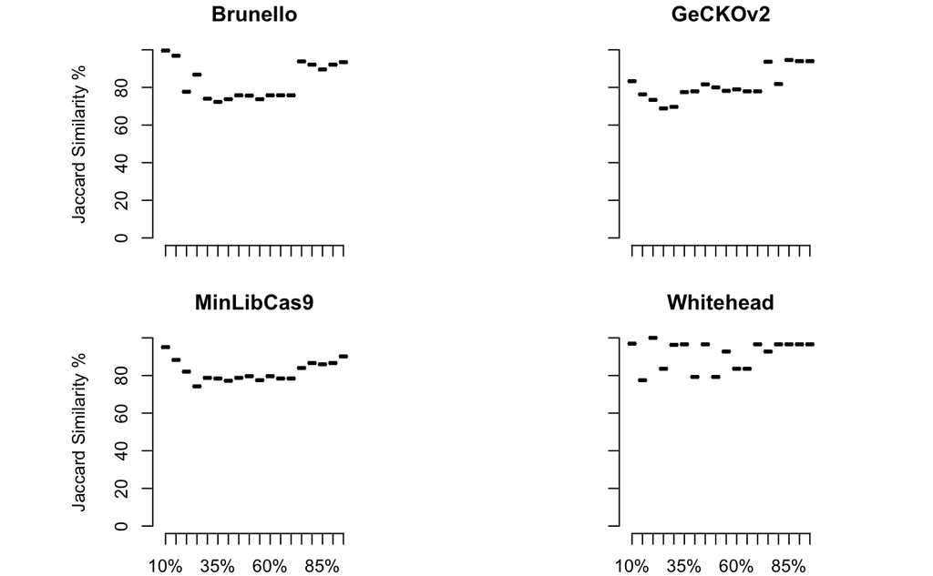

```r
source('R/Validation.R')

load('data/Rankings/Library_independent/Final_es_ranking.RData')
load('data/Rankings/Library_independent/Final_nones_ranking.RData')

validation_ind_lib(final_es,final_nones,BAGEL_essential,BAGEL_nonEssential)
```